# Modeling and prediction for IMDB scoring system of movies

### *Analysed by **Kashif Nawaz***

## Setup

### Load packages

```r
library(ggplot2)
library(dplyr)
library(statsr)
library(scales)
require(gridExtra)
library(broom)
```

### Load data

```r
load("movies.RData")
```

## Part 1: Data

The given dataset contain 651 randomly selected movies information collected from IMDB and Rotten Tomatoes. All 651 movies are released between 1970 to 2014, and the number of variables for each observation are 32; description of each variable shown here. The method of collection of this dataset and for the purpose of this project it is only possible to do an observational study and no causal analysis is done. The study can generalize for movies released between 1970 to 2014.

Because some of the variables are irrelevant to the purpose this project which is identifying the popularity of a movie, they are removed.

```r
my_movies <- movies[,c(3,13,16,18,20,21,23,24)]
```

## Part 2: Research question

For the present study we want to determine how does the

*genre of movie*,

*critics score*,

*audience score*,

*whether or not the movie won a best picture Oscar*,

*whether or not one of the main actors/director in the movie ever won an Oscar* and

*whether or not the movie is in the Top 200 Box Office list on BoxOfficeMojo*

affects or relates to the IMDB score of a movie?

Answering this question can leads to determine what features are more dominant to obtain the IMDB scoring system.

## Part 3: Exploratory data analysis

To get the overall idea of the whole dataset we first use *summary* command, which yield the description of each and every variable (column).

```r
summary(my_movies)
```

```
##                 genre      imdb_rating    critics_score    audience_score
##  Drama             :305   Min.   :1.900   Min.   :  1.00   Min.   :11.00
##  Comedy            : 87   1st Qu.:5.900   1st Qu.: 33.00   1st Qu.:46.00
##  Action & Adventure: 65   Median :6.600   Median : 61.00   Median :65.00
##  Mystery & Suspense: 59   Mean   :6.493   Mean   : 57.69   Mean   :62.36
##  Documentary       : 52   3rd Qu.:7.300   3rd Qu.: 83.00   3rd Qu.:80.00
##  Horror            : 23   Max.   :9.000   Max.   :100.00   Max.   :97.00
##  (Other)           : 60
##  best_pic_win best_actor_win best_dir_win top200_box
##  no :644      no :558        no :608      no :636
##  yes:  7      yes: 93        yes: 43      yes: 15
##
##
##
##
##
```

*Table1: Summary statistics of whole dataset*

As you can see here variable **genre** has 11 different categories. Apart from that variable **best_pic_win**, **best_actor_win**, and **best_dir_win** are categorical variable with output yes or no. All these 4 categorical variable are shown in the form of barplot in figure 1.

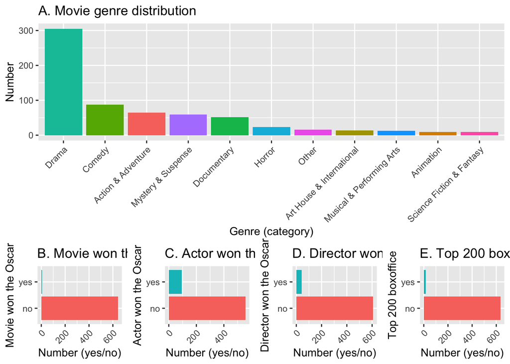

```r
p1 <- ggplot(my_movies %>% count(genre) %>% mutate(num = n ), aes(x = reorder(genre, -num), y = num,fill=genre)) + geom_bar(stat = "identity") + theme(axis.text.x = element_text(angle = 45, hjust = 1)) + ggtitle("A. Movie genre distribution") +  xlab("Genre (category)") + ylab("Number") +theme(legend.position = "none")
p2 <- ggplot(my_movies, aes(best_pic_win,fill=best_pic_win)) + geom_bar() + theme(axis.text.x = element_text(angle = 45, hjust = 1)) + ggtitle("B. Movie won the Oscar") +  xlab("Movie won the Oscar") + ylab("Number (yes/no)")+theme(legend.position = "none")
p3 <- ggplot(my_movies, aes(best_actor_win,fill=best_actor_win)) + geom_bar() + theme(axis.text.x = element_text(angle = 45, hjust = 1)) + ggtitle("C. Actor won the Oscar") +  xlab("Actor won the Oscar") + ylab("Number (yes/no)")+theme(legend.position = "none")
p4 <- ggplot(my_movies, aes(best_dir_win,fill=best_dir_win)) + geom_bar() + theme(axis.text.x = element_text(angle = 45, hjust = 1)) + ggtitle("D. Director won the Oscar") +  xlab("Director won the Oscar") + ylab("Number (yes/no)")+theme(legend.position = "none")
p5 <- ggplot(my_movies, aes(top200_box,fill=top200_box)) + geom_bar() + theme(axis.text.x = element_text(angle = 45, hjust = 1)) + ggtitle("E. Top 200 boxoffice") +  xlab("Top 200 boxoffice") + ylab("Number (yes/no)")+theme(legend.position = "none")
grid.arrange(p1, p2+coord_flip(),p3+coord_flip(),p4+coord_flip(),p5+coord_flip(), nrow = 2, layout_matrix = rbind(c(1, 1, 1,1),c(1, 1, 1,1),c(1, 1, 1,1),c(1, 1, 1,1),c(1, 1, 1,1),c(1, 1, 1,1),c(1, 1, 1,1),c(1, 1, 1,1),c(2, 3, 4,5),c(2, 3, 4,5),c(2, 3, 4,5),c(2, 3, 4,5)))
```

*Figure 1: Barplots for Genre of movies, best picture award, main actors award and director award.*

Along with the above 4 categorical variable there are 3 numerical variable: **imdb_rating**, **critics_score**, **audience_score**. Density plot of these are shown in figure 2. Vertical dashed line is mean of the respective sample.

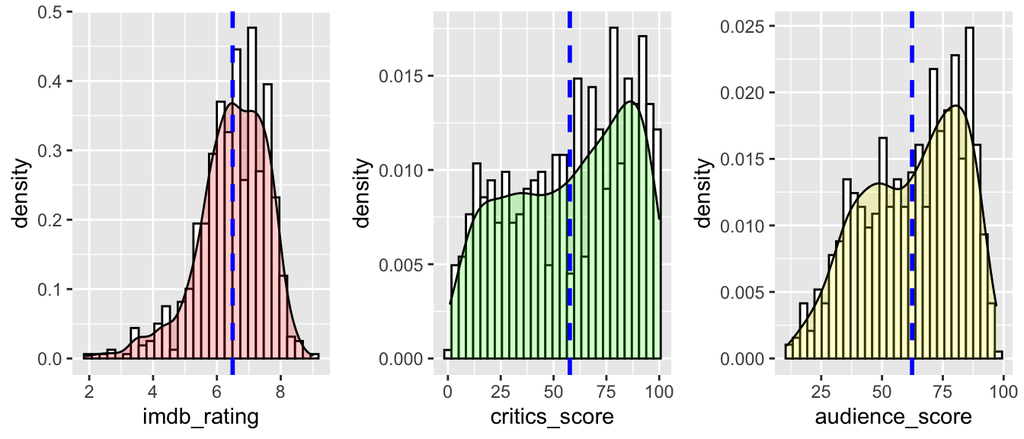

```r
p1 <- ggplot(my_movies, aes(x=imdb_rating)) + geom_histogram(aes(y=..density..), colour="black", fill="white")+ geom_density(alpha=.2, fill="red") + geom_vline(aes(xintercept=mean(imdb_rating)), color="blue", linetype="dashed", size=1)
p2 <- ggplot(my_movies, aes(x=critics_score)) + geom_histogram(aes(y=..density..), colour="black", fill="white")+ geom_density(alpha=.2, fill="green") + geom_vline(aes(xintercept=mean(critics_score)), color="blue", linetype="dashed", size=1)
p3 <- ggplot(my_movies, aes(x=audience_score)) + geom_histogram(aes(y=..density..), colour="black", fill="white")+ geom_density(alpha=.2, fill="yellow") + geom_vline(aes(xintercept=mean(audience_score)), color="blue", linetype="dashed", size=1)
grid.arrange(p1, p2,p3, nrow = 1, ncol = 3, layout_matrix = rbind(c(1, 2, 3)))
```

*Figure 2: Density plot of IMDB rating, Critics score and Audience score. Blue dashed line is mean of respective sample.*

[figure not shown]

```r
p1 <- ggplot(my_movies, aes(x=imdb_rating, y=best_pic_win, group=best_pic_win, fill=best_pic_win)) + geom_boxplot(outlier.size = -1) + theme(axis.text.x = element_text(angle = 0, hjust = 1)) + ggtitle("A. IMDB: Movie") +  xlab("IMDB rating")+ylab("Movie-Oscar-win") + coord_flip() + stat_boxplot(geom ='errorbar',width=0.3)+theme(legend.position = "none")
p2 <- ggplot(my_movies, aes(x=critics_score, y=best_pic_win, group=best_pic_win, fill=best_pic_win)) + geom_boxplot(outlier.size = -1) + theme(axis.text.x = element_text(angle = 0, hjust = 1)) + ggtitle("B. Critics: Movie") +  xlab("Critics score")+ylab("Movie-Oscar-win") + coord_flip() + stat_boxplot(geom ='errorbar',width=0.3)+theme(legend.position = "none")
p3 <- ggplot(my_movies, aes(x=audience_score, y=best_pic_win, group=best_pic_win, fill=best_pic_win)) + geom_boxplot(outlier.size = -1) + theme(axis.text.x = element_text(angle = 0, hjust = 1)) + ggtitle("C. Audience: Movie") +  xlab("Audience score")+ylab("Movie-Oscar-win") + coord_flip() + stat_boxplot(geom ='errorbar',width=0.3)+theme(legend.position = "none")
p4 <- ggplot(my_movies, aes(x=imdb_rating, y=best_dir_win, group=best_dir_win, fill=best_dir_win)) + geom_boxplot(outlier.size = -1) + theme(axis.text.x = element_text(angle = 0, hjust = 1)) + ggtitle("D. IMDB: Director") +  xlab("IMDB rating")+ylab("Director-Oscar-win") + coord_flip() + stat_boxplot(geom ='errorbar',width=0.3)+theme(legend.position = "none")
p5 <- ggplot(my_movies, aes(x=critics_score, y=best_dir_win, group=best_dir_win, fill=best_dir_win)) + geom_boxplot(outlier.size = -1) + theme(axis.text.x = element_text(angle = 0, hjust = 1)) + ggtitle("E. Critics: Director") +  xlab("Critics score")+ylab("Director-Oscar-win") + coord_flip() + stat_boxplot(geom ='errorbar',width=0.3)+theme(legend.position = "none")
p6 <- ggplot(my_movies, aes(x=audience_score, y=best_dir_win, group=best_dir_win, fill=best_dir_win)) + geom_boxplot(outlier.size = -1) + theme(axis.text.x = element_text(angle = 0, hjust = 1)) + ggtitle("F. Audience: Director") +  xlab("Audience score")+ylab("Director-Oscar-win") + coord_flip() + stat_boxplot(geom ='errorbar',width=0.3)+theme(legend.position = "none")
p7 <- ggplot(my_movies, aes(x=imdb_rating, y=best_actor_win, group=best_actor_win, fill=best_actor_win)) + geom_boxplot(outlier.size = -1) + theme(axis.text.x = element_text(angle = 0, hjust = 1)) + ggtitle("G. IMDB: Actor") +  xlab("IMDB rating")+ylab("Actor-Oscar-win") + coord_flip() + stat_boxplot(geom ='errorbar',width=0.3)+theme(legend.position = "none")
p8 <- ggplot(my_movies, aes(x=critics_score, y=best_actor_win, group=best_actor_win, fill=best_actor_win)) + geom_boxplot(outlier.size = -1) + theme(axis.text.x = element_text(angle = 0, hjust = 1)) + ggtitle("H. Critics: Actor") +  xlab("Critics score")+ylab("Actor-Oscar-win") + coord_flip() + stat_boxplot(geom ='errorbar',width=0.3)+theme(legend.position = "none")
p9 <- ggplot(my_movies, aes(x=audience_score, y=best_actor_win, group=best_actor_win, fill=best_actor_win)) + geom_boxplot(outlier.size = -1) + theme(axis.text.x = element_text(angle = 0, hjust = 1)) + ggtitle("I. Audience: Actor") +  xlab("Audience score")+ylab("Actor-Oscar-win") + coord_flip() + stat_boxplot(geom ='errorbar',width=0.3)+theme(legend.position = "none")
p10 <- ggplot(my_movies, aes(x=imdb_rating, y=top200_box, group=top200_box, fill=top200_box)) + geom_boxplot(outlier.size = -1) + theme(axis.text.x = element_text(angle = 0, hjust = 1)) + ggtitle("J. IMDB: Actor") +  xlab("IMDB rating")+ylab("Actor-Oscar-win") + coord_flip() + stat_boxplot(geom ='errorbar',width=0.3)+theme(legend.position = "none")
p11 <- ggplot(my_movies, aes(x=critics_score, y=top200_box, group=top200_box, fill=top200_box)) + geom_boxplot(outlier.size = -1) + theme(axis.text.x = element_text(angle = 0, hjust = 1)) + ggtitle("K. Critics: Actor") +  xlab("Critics score")+ylab("Actor-Oscar-win") + coord_flip() + stat_boxplot(geom ='errorbar',width=0.3)+theme(legend.position = "none")
p12 <- ggplot(my_movies, aes(x=audience_score, y=top200_box, group=top200_box, fill=top200_box)) + geom_boxplot(outlier.size = -1) + theme(axis.text.x = element_text(angle = 0, hjust = 1)) + ggtitle("L. Audience: Actor") +  xlab("Audience score")+ylab("Actor-Oscar-win") + coord_flip() + stat_boxplot(geom ='errorbar',width=0.3)+theme(legend.position = "none")
grid.arrange(p1, p2,p3,p4,p5,p6,p7,p8,p9,p10,p11,p12, nrow = 4, ncol = 3, layout_matrix = rbind(c(1, 2, 3), c(4, 5, 6), c(7, 8, 9), c(10, 11, 12)))
```

*Figure 3: Boxplots of IMDB rating, Critics score and Audience score in context of each categorical variable (except genre). First row in context of best_pic_win, second row: best_dir_win, third row: best_actor_win and fourth row in context of top200_box.*

To measure the central tendency of numerical variable (IMDB rating, Critics score and Audience score), we plotted the boxplot, and each boxplot is subdivided into yes and no, in terms of each categorical variable (best_pic_win, best_dir_win, best_actor_win and top200_box).

## Part 4: Modeling

First, we fitted the model (my_model) with all 7 explanatory variables, which yielded adjusted R2 of 0.8093 with the significance of p-value: < 2.2e-16. This my_model is described in table 2.

```r
my_model <- lm(imdb_rating~.,data=my_movies)
summary(my_model)
```

```
##
## Call:
## lm(formula = imdb_rating ~ ., data = my_movies)
##
## Residuals:
##      Min       1Q   Median       3Q      Max
## -2.38851 -0.21783  0.03609  0.28204  1.18985
##
## Coefficients:
##                                  Estimate Std. Error t value Pr(>|t|)
## (Intercept)                     3.6696098  0.0812957  45.139  < 2e-16 ***
## genreAnimation                 -0.4493989  0.1691599  -2.657  0.00809 **
## genreArt House & International  0.2061071  0.1406223   1.466  0.14323
## genreComedy                    -0.1721538  0.0781703  -2.202  0.02800 *
## genreDocumentary                0.2312383  0.0964460   2.398  0.01679 *
## genreDrama                      0.0805342  0.0673330   1.196  0.23212
## genreHorror                     0.0528870  0.1160968   0.456  0.64887
## genreMusical & Performing Arts  0.0589347  0.1523471   0.387  0.69900
## genreMystery & Suspense         0.2758101  0.0868292   3.176  0.00156 **
## genreOther                     -0.0330683  0.1334869  -0.248  0.80443
## genreScience Fiction & Fantasy -0.2026863  0.1690347  -1.199  0.23094
## critics_score                   0.0103740  0.0009608  10.797  < 2e-16 ***
## audience_score                  0.0344191  0.0013410  25.668  < 2e-16 ***
## best_pic_winyes                 0.1638771  0.1925748   0.851  0.39510
## best_actor_winyes               0.0854894  0.0544839   1.569  0.11713
## best_dir_winyes                 0.1166646  0.0805531   1.448  0.14803
## top200_boxyes                   0.0487478  0.1271527   0.383  0.70157
## ---
## Signif. codes:  0 '***' 0.001 '**' 0.01 '*' 0.05 '.' 0.1 ' ' 1
##
## Residual standard error: 0.4737 on 634 degrees of freedom
## Multiple R-squared:  0.814,  Adjusted R-squared:  0.8093
## F-statistic: 173.4 on 16 and 634 DF,  p-value: < 2.2e-16
```

*Table 2: Initial fitted model with all 7 explanatory variables.*

```r
final_model<-step(my_model, direction = "both", trace=FALSE )
summary(final_model)
```

```
##
## Call:
## lm(formula = imdb_rating ~ genre + critics_score + audience_score +
##     best_actor_win + best_dir_win, data = my_movies)
##
## Residuals:
##      Min       1Q   Median       3Q      Max
## -2.38646 -0.22317  0.03395  0.28041  1.19107
##
## Coefficients:
##                                  Estimate Std. Error t value Pr(>|t|)
## (Intercept)                     3.6649223  0.0808909  45.307  < 2e-16 ***
## genreAnimation                 -0.4530532  0.1686559  -2.686  0.00741 **
## genreArt House & International  0.2023602  0.1400776   1.445  0.14905
## genreComedy                    -0.1729638  0.0776135  -2.229  0.02619 *
## genreDocumentary                0.2238917  0.0952404   2.351  0.01904 *
## genreDrama                      0.0777453  0.0665502   1.168  0.24316
## genreHorror                     0.0502006  0.1156373   0.434  0.66435
## genreMusical & Performing Arts  0.0504856  0.1515496   0.333  0.73915
## genreMystery & Suspense         0.2736724  0.0862465   3.173  0.00158 **
## genreOther                     -0.0363037  0.1332880  -0.272  0.78543
## genreScience Fiction & Fantasy -0.2022056  0.1688297  -1.198  0.23148
## critics_score                   0.0104296  0.0009573  10.895  < 2e-16 ***
## audience_score                  0.0345061  0.0013362  25.824  < 2e-16 ***
## best_actor_winyes               0.0865839  0.0543712   1.592  0.11178
## best_dir_winyes                 0.1384508  0.0764371   1.811  0.07057 .
## ---
## Signif. codes:  0 '***' 0.001 '**' 0.01 '*' 0.05 '.' 0.1 ' ' 1
##
## Residual standard error: 0.4733 on 636 degrees of freedom
## Multiple R-squared:  0.8138, Adjusted R-squared:  0.8097
## F-statistic: 198.5 on 14 and 636 DF,  p-value: < 2.2e-16
```

*Table 3: Final fitted model (final_model) with all 5 explanatory variables.*

Here, adjusted R2 become **0.8097** which means nearly 81% of the data can be explainable with this model.

To check how significant or authentic our final model is we plotted residual scatter plot, residual histogram and residual vs fitted scatter plot.

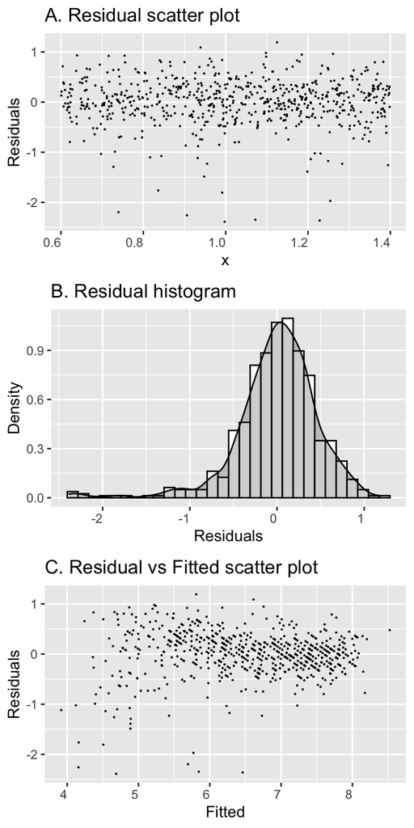

```r
df <- augment(final_model)
p1 <- ggplot() + geom_jitter(data=df, aes(y=.resid, x=1),size = .1) + theme(axis.text.x = element_text(angle = 0, hjust = 1)) + ggtitle("A. Residual scatter plot") +ylab("Residuals")
p2 <- ggplot(df, aes(x=.resid)) + geom_histogram(aes(y=..density..), colour="black", fill="white")+ geom_density(alpha=.2, fill="black") + theme(axis.text.x = element_text(angle = 0, hjust = 1)) + ggtitle("B. Residual histogram") +xlab("Residuals") + ylab("Density")
p3 <- ggplot() + geom_jitter(data=df, aes(y=.resid, x=.fitted),size = .1) + theme(axis.text.x = element_text(angle = 0, hjust = 1)) + ggtitle("C. Residual vs Fitted scatter plot") +ylab("Residuals") + xlab("Fitted")

grid.arrange(p1, p2, p3, nrow = 3, ncol = 1)
```

*Figure 4: A. Residual scatter plot, B. Residual histogram and C. Residual vs fitted scatter plot.*

Along with this we also plotted qqnorm plot.

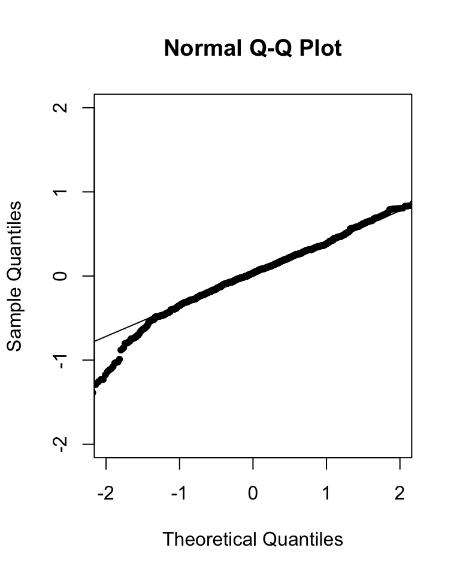

```r
qqnorm(resid(final_model), pch=20, xlim=c(-2,2), ylim = c(-2,2))
qqline(resid(final_model))
```

*Figure 5: A. Normal Q-Q plot.*

Residual histogram (Fig. 4B) show left skewness but qqnorm plot shows (Fig. 5) deviation in tail regions. Residual scatted plot (Fig. 4A) shown that residuals scattered along 0, which is another indication of better model.

We also plotted the residuals vs other 2 numerical variables (Critics score and Audience score) to see the fitness of the model.

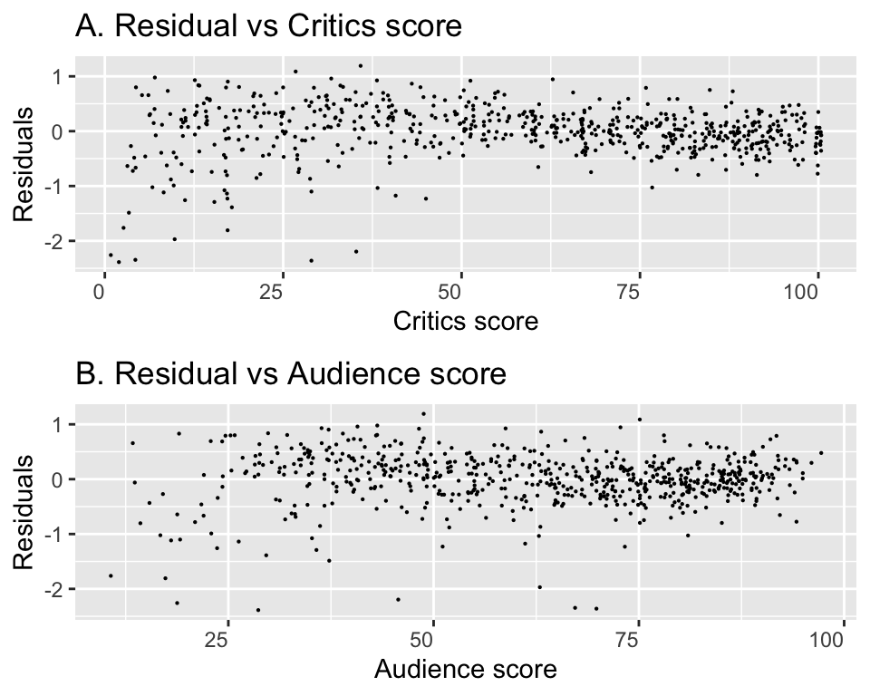

```r
p1 <- ggplot() + geom_jitter(data=df, aes(y=.resid, x=critics_score),size = .1) + theme(axis.text.x = element_text(angle = 0, hjust = 1)) + ggtitle("A. Residual vs Critics score") +ylab("Residuals") + xlab("Critics score")
p2 <- ggplot() + geom_jitter(data=df, aes(y=.resid, x=audience_score),size = .1) + theme(axis.text.x = element_text(angle = 0, hjust = 1)) + ggtitle("B. Residual vs Audience score") +ylab("Residuals") + xlab("Audience score")
grid.arrange(p1, p2, nrow = 2, ncol = 1)
```

*Figure 6: A. Residual vs Critics score, B. Residual vs Audience score.*

## Part 5: Prediction

For prediction the IMDB rating for a new movie from 2016 with our model, we selected **“Moonlight”** which has a score of 8. Its genre is set as “Drama”, critics_score = 98%, audience_score = 79%, best_actor_win = no and best_dir_win = no. All these data were taken from Google search.

```r
new_movie<-data.frame(genre="Drama",critics_score = 98, audience_score = 79, best_actor_win = "no", best_dir_win = "no")
predict(final_model,new_movie)
```

```
##        1
## 7.490747
```

```r
predict(final_model, new_movie, interval="predict")
```

```
##        fit      lwr      upr
## 1 7.490747 6.558033 8.423461
```

## Part 6: Conclusion

IMDB is the most famous scoring system on which general public rely before watching a movie. Determining the popularity of a movie is not simple task. Few essential qualities of a movie seem to have some degree of correlation with its IMDB score. Elseways, some external characteristics, like genre, scores from critics and audience, and best actor and director Oscar winning status also correlated or contributing to IMDB score of that particular movie. One drawback is we only used a subset of numerous features for our initial model, much better model could be modeled using all the set of information or a combination of some important information.